# Lecture 2

`tidyverse` - `ggplot2` + `dplyr`

Pablo Benavides-Herrera

2020-05-30

We load the packages and take a look at the data `mpg`.

```r
library(tidyverse)
library(nycflights13)
mpg
```

| manufacturer | model | displ | year | cyl | trans | drv | cty | hwy | fl | class |
| --- | --- | --- | --- | --- | --- | --- | --- | --- | --- | --- |
| audi | a4 | 1.8 | 1999 | 4 | auto(l5) | f | 18 | 29 | p | compact |
| audi | a4 | 1.8 | 1999 | 4 | manual(m5) | f | 21 | 29 | p | compact |
| audi | a4 | 2.0 | 2008 | 4 | manual(m6) | f | 20 | 31 | p | compact |
| audi | a4 | 2.0 | 2008 | 4 | auto(av) | f | 21 | 30 | p | compact |
| audi | a4 | 2.8 | 1999 | 6 | auto(l5) | f | 16 | 26 | p | compact |
| audi | a4 | 2.8 | 1999 | 6 | manual(m5) | f | 18 | 26 | p | compact |
| audi | a4 | 3.1 | 2008 | 6 | auto(av) | f | 18 | 27 | p | compact |
| audi | a4 quattro | 1.8 | 1999 | 4 | manual(m5) | 4 | 18 | 26 | p | compact |
| audi | a4 quattro | 1.8 | 1999 | 4 | auto(l5) | 4 | 16 | 25 | p | compact |
| audi | a4 quattro | 2.0 | 2008 | 4 | manual(m6) | 4 | 20 | 28 | p | compact |

[output cut: 224 more lines]

# Using the `qplot()` function

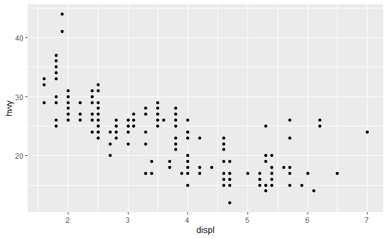

```r
qplot(displ, hwy, data = mpg)
```

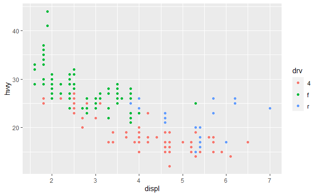

```r
qplot(displ, hwy, data = mpg, color = drv)
```

Now we change the `shape` of the points.

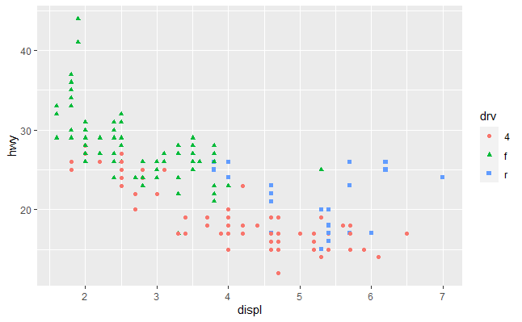

```r
qplot(displ, hwy, data = mpg, color = drv, shape = drv)
```

Now we add two geoms: points and smooth.

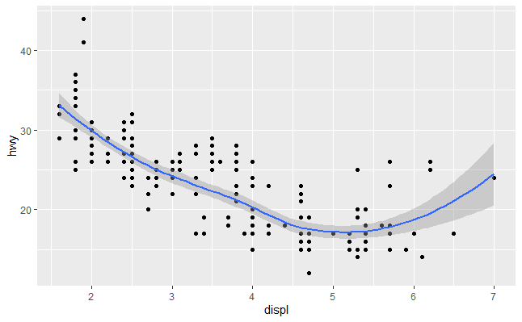

```r
qplot(displ, hwy, data = mpg, geom = c("point", "smooth"))
```

Smoothing across groups.

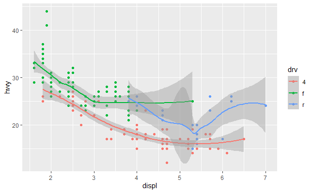

```r
qplot(displ, hwy, data = mpg, color = drv,
      geom = c("point", "smooth"))
```

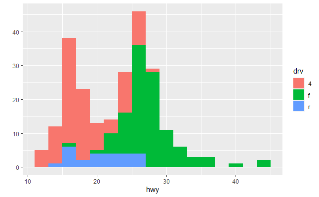

```r
qplot(hwy, data = mpg, fill = drv, binwidth = 2)
```

Plotting boxplots of `drv` and `hwy`.

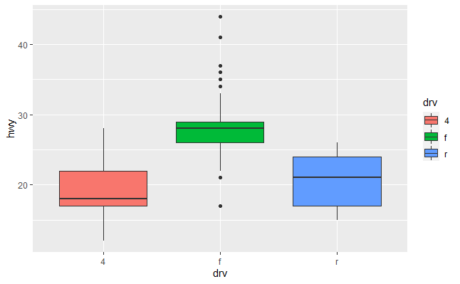

```r
qplot(drv, hwy, data = mpg, fill = drv, geom = "boxplot")
```

We can plot the histograms with facets.

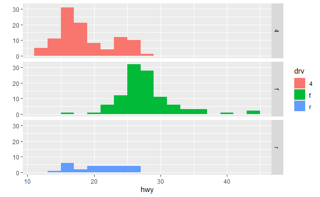

```r
qplot(hwy, data = mpg, fill = drv,
      facets = drv~., binwidth = 2)
```

Scatterplots can have facets too.

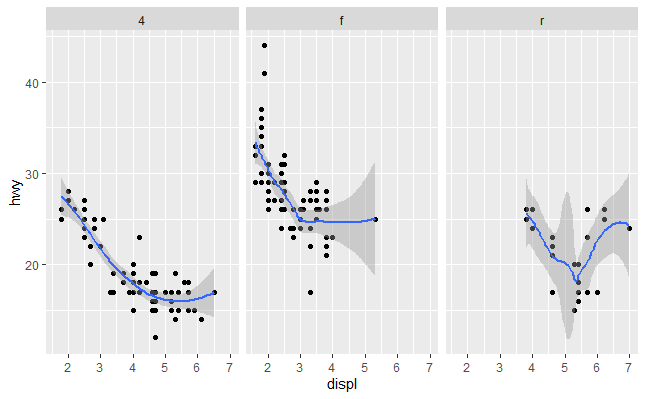

```r
qplot(displ, hwy, data = mpg, facets = . ~ drv,
      geom = c("point","smooth"))
```

Getting the density plot.

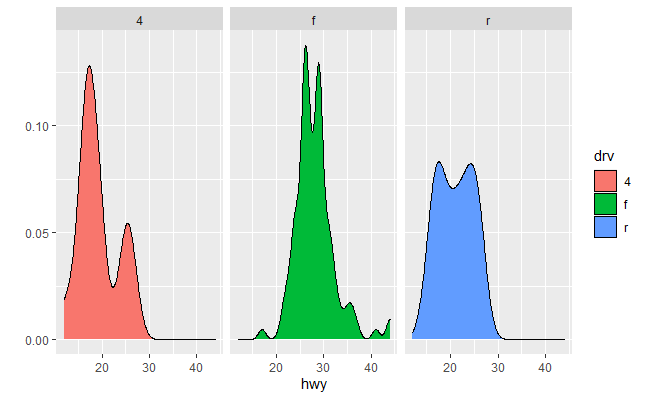

```r
qplot(hwy, data = mpg, fill = drv,
      facets = . ~ drv,
      geom = "density")
```

# Translating `qplot()` into `ggplot()`

We’ll do the same, but now using the `ggplot()` function.

The basic settings:

```r
g <- ggplot(data = mpg)
g1 <- g + aes(x = hwy)
g2 <- g + aes(x = displ, y = hwy)
g3 <- g + aes(x = drv, y = hwy)
```

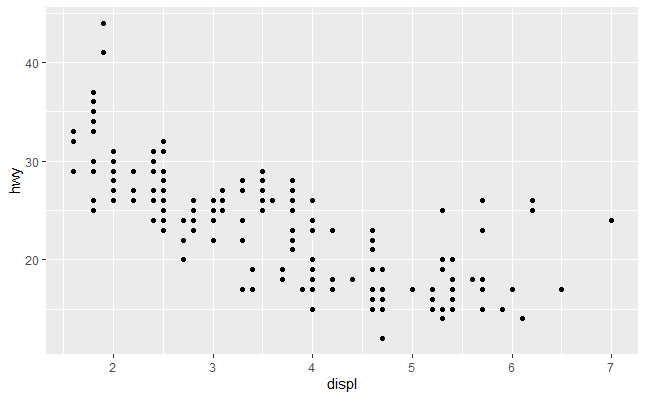

```r
g2 + geom_point()
```

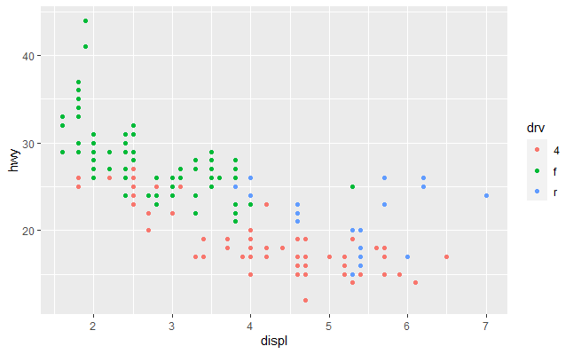

```r
g2 + geom_point(aes(color = drv))
```

Now we change the `shape` of the points.

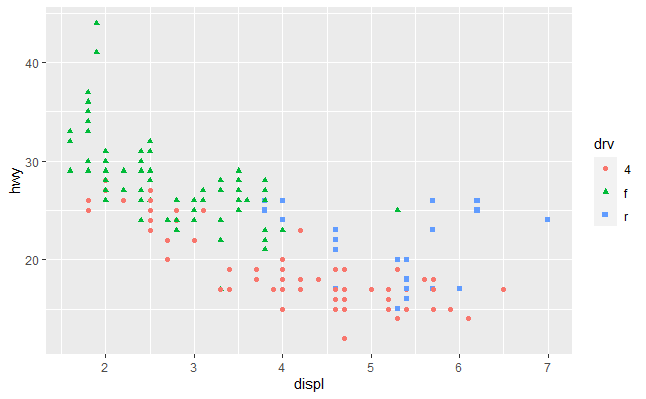

```r
g2 + geom_point(aes(color = drv, shape = drv))
```

Now we add two geoms: points and smooth.

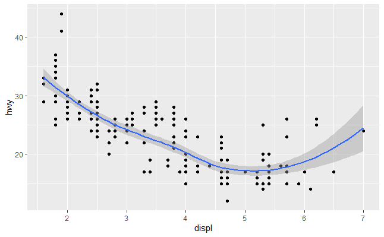

```r
g2 + geom_point() + geom_smooth()
```

Smoothing across groups.

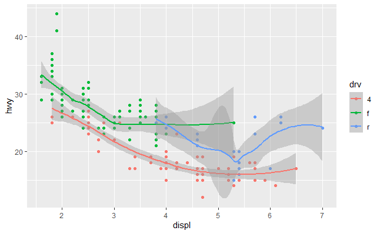

```r
g2 + geom_point(aes(color = drv)) +
  geom_smooth(aes(color = drv))
```

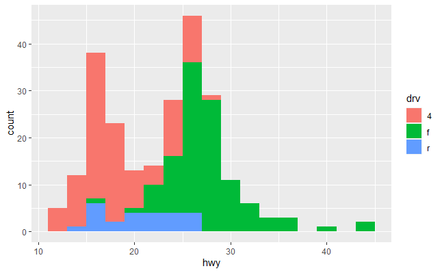

```r
g1 + geom_histogram(aes(fill = drv), binwidth = 2)
```

Plotting boxplots of `drv` and `hwy`.

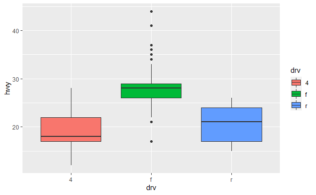

```r
g3 + geom_boxplot(aes(fill = drv))
```

We can plot the histograms with facets.

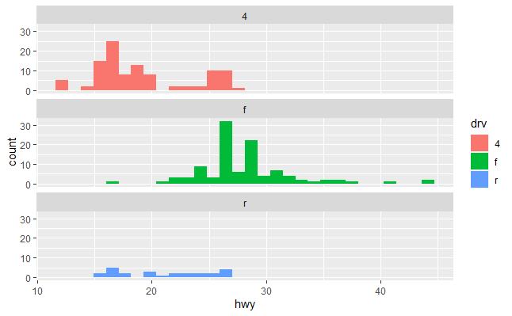

```r
g1 + geom_histogram(aes(fill = drv)) +
  facet_wrap(~drv, ncol = 1)
```

Scatterplots can have facets too.

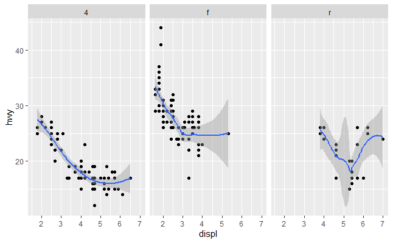

```r
g2 + geom_point() + geom_smooth() +
  facet_wrap(~ drv, nrow = 1)
```

Getting the density plot.

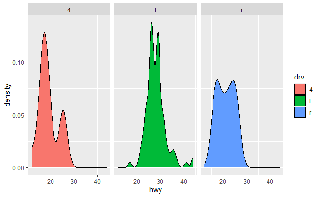

```r
g1 + geom_density(aes(fill = drv)) +
  facet_wrap(~ drv, nrow = 1)
```

# Mouse Allergen and Asthma Cohort Study (MAACS)

“Are overweight individuals, as measured by body mass index (BMI), more susceptible than normal weight individuals to the harmful effects of PM2.5 on asthma symptoms?”

https://laqm.defra.gov.uk/public-health/pm25.html

NocturnalSymp, is the number of days in the past 2 weeks where the child experienced asthma symptoms (e.g. coughing, wheezing) while sleeping.

```r
maacs <- read_csv("bmi_pm25_no2_sim.csv")
glimpse(maacs)
```

```
Rows: 517
Columns: 4
$ logpm25        <dbl> 1.2476997, 1.1216476, 1.9300429...
$ logno2_new     <dbl> 1.1837987, 1.5515362, 1.4323519...
$ bmicat         <chr> "normal weight", "overweight", ...
$ NocturnalSympt <dbl> 1, 0, 0, 2, 0, 0, 0, 0, 0, 3, 0...
```

```r
maacs
```

| logpm25 | logno2_new | bmicat | NocturnalSympt |
| --- | --- | --- | --- |
| 1.2476997 | 1.1837987 | normal weight | 1 |
| 1.1216476 | 1.5515362 | overweight | 0 |
| 1.9300429 | 1.4323519 | normal weight | 0 |
| 1.3679246 | 1.7736804 | overweight | 2 |
| 0.7753367 | 0.7654826 | normal weight | 0 |
| 1.4872785 | 1.1127378 | normal weight | 0 |
| 2.1615575 | 1.4313160 | normal weight | 0 |
| 1.6456305 | 1.4042644 | normal weight | 0 |
| 1.5544083 | 1.8080814 | normal weight | 0 |
| 2.0394687 | 1.3515510 | overweight | 3 |

[output cut: 507 more lines]

```r
g <- ggplot(data = maacs,
            aes(x = logpm25, y = NocturnalSympt))
summary(g)
```

```
data: logpm25, logno2_new, bmicat, NocturnalSympt
  [517x4]
mapping:  x = ~logpm25, y = ~NocturnalSympt
faceting: <ggproto object: Class FacetNull, Facet, gg>
    compute_layout: function
    draw_back: function
    draw_front: function
    draw_labels: function
    draw_panels: function
    finish_data: function
    init_scales: function
    map_data: function
    params: list
    setup_data: function
    setup_params: function
    shrink: TRUE
    train_scales: function
    vars: function
    super:  <ggproto object: Class FacetNull, Facet, gg>
```

With no geom, the plot is empty.

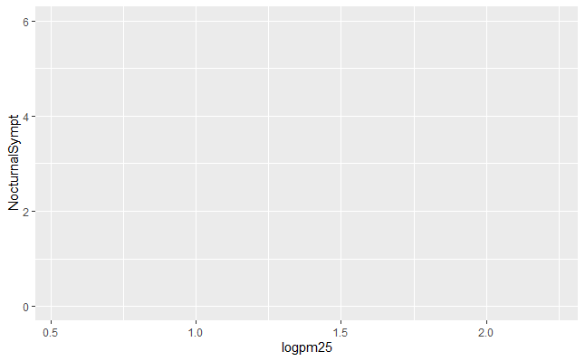

```r
print(g)
```

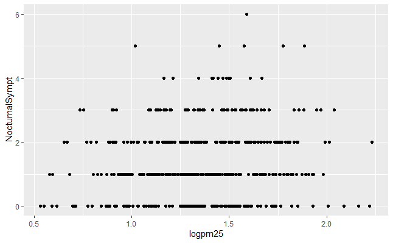

```r
g + geom_point()
```

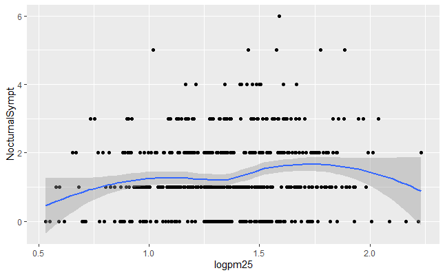

```r
g + geom_point() + geom_smooth()
```

Changing the smoothing method.

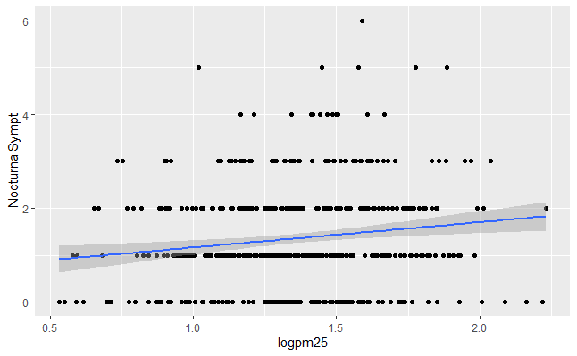

```r
g + geom_point() + geom_smooth(method = "lm")
```

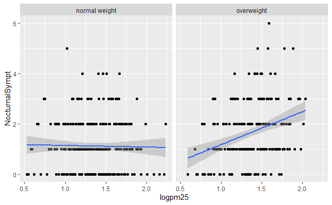

```r
g + geom_point() + geom_smooth(method = "lm") +
  facet_wrap(~ bmicat)
```

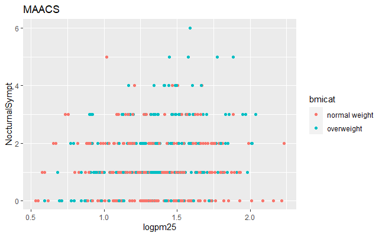

```r
g + geom_point(aes(color = bmicat)) +
  labs(title = "MAACS")
```

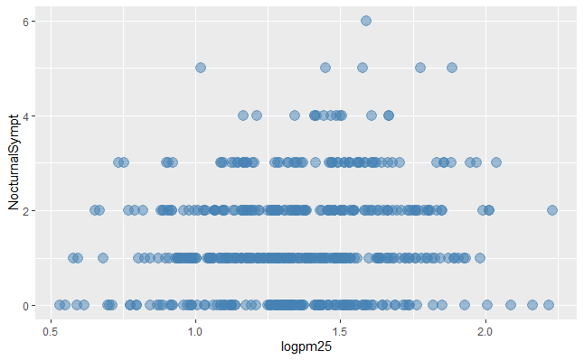

```r
g + geom_point(color = "steelblue", size = 4, alpha = 1/2)
```

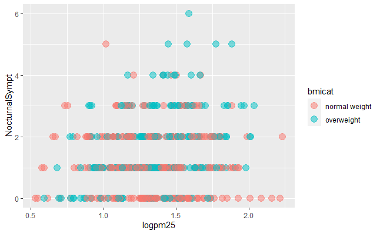

```r
g + geom_point(aes(color = bmicat), size = 4, alpha = 1/2)
```

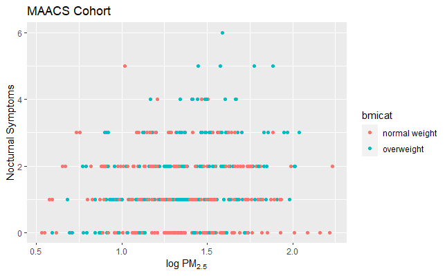

```r
g + geom_point(aes(color = bmicat)) +
  labs(title = "MAACS Cohort",
       x = expression("log " * PM[2.5]),
       y = "Nocturnal Symptoms")
```

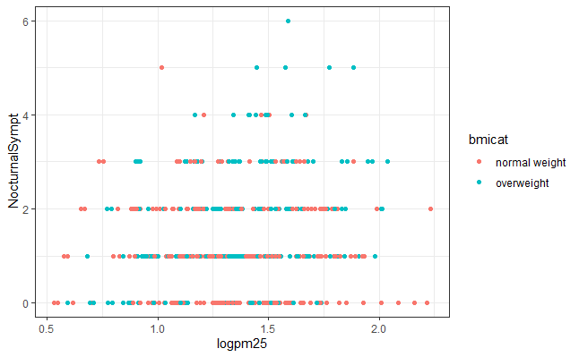

```r
g + geom_point(aes(color = bmicat)) +
  theme_bw(base_family = "Times")
```

```r
testdat <- data.frame(x = 1:100, y = rnorm(100))
```

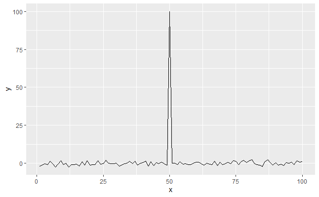

```r
testdat[50,2] <- 100  ## Outlier!
g <- ggplot(testdat, aes(x = x, y = y))
g + geom_line()
```

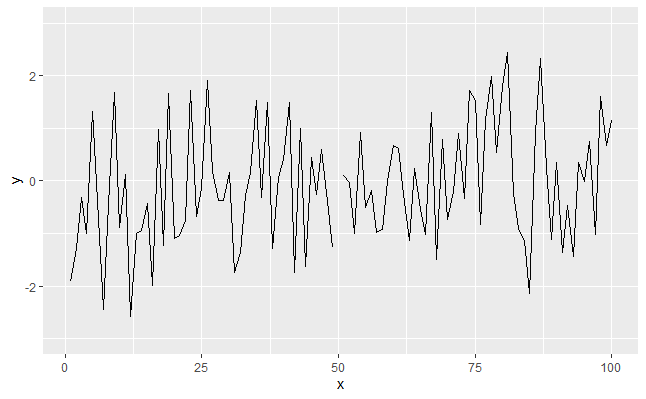

```r
g + geom_line() + ylim(-3, 3)
```

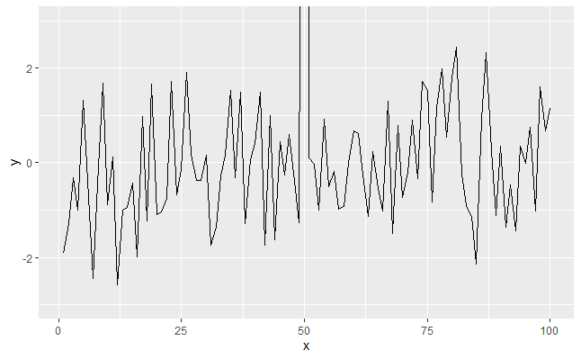

```r
p <- g + geom_line() + coord_cartesian(ylim = c(-3, 3))
p
```

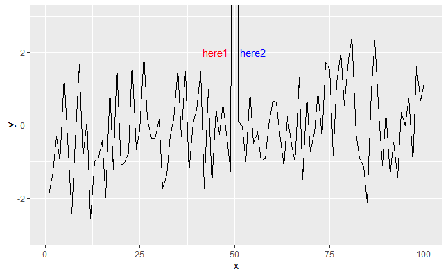

```r
p + annotate("text", x = c(45,55), y = c(2,2), label = c("here1", "here2"),
             color = c("red", "blue"))
```

# The `nycflights13` dataset

```r
flights
```

| year | month | day | dep_time | sched_dep_time | dep_delay | arr_time | sched_arr_time | arr_delay | carrier | flight | tailnum | origin | dest | air_time | distance | hour | minute | time_hour |
| --- | --- | --- | --- | --- | --- | --- | --- | --- | --- | --- | --- | --- | --- | --- | --- | --- | --- | --- |
| 2013 | 1 | 1 | 517 | 515 | 2 | 830 | 819 | 11 | UA | 1545 | N14228 | EWR | IAH | 227 | 1400 | 5 | 15 | 2013-01-01 05:00:00 |
| 2013 | 1 | 1 | 533 | 529 | 4 | 850 | 830 | 20 | UA | 1714 | N24211 | LGA | IAH | 227 | 1416 | 5 | 29 | 2013-01-01 05:00:00 |
| 2013 | 1 | 1 | 542 | 540 | 2 | 923 | 850 | 33 | AA | 1141 | N619AA | JFK | MIA | 160 | 1089 | 5 | 40 | 2013-01-01 05:00:00 |
| 2013 | 1 | 1 | 544 | 545 | -1 | 1004 | 1022 | -18 | B6 | 725 | N804JB | JFK | BQN | 183 | 1576 | 5 | 45 | 2013-01-01 05:00:00 |
| 2013 | 1 | 1 | 554 | 600 | -6 | 812 | 837 | -25 | DL | 461 | N668DN | LGA | ATL | 116 | 762 | 6 | 0 | 2013-01-01 06:00:00 |
| 2013 | 1 | 1 | 554 | 558 | -4 | 740 | 728 | 12 | UA | 1696 | N39463 | EWR | ORD | 150 | 719 | 5 | 58 | 2013-01-01 05:00:00 |
| 2013 | 1 | 1 | 555 | 600 | -5 | 913 | 854 | 19 | B6 | 507 | N516JB | EWR | FLL | 158 | 1065 | 6 | 0 | 2013-01-01 06:00:00 |
| 2013 | 1 | 1 | 557 | 600 | -3 | 709 | 723 | -14 | EV | 5708 | N829AS | LGA | IAD | 53 | 229 | 6 | 0 | 2013-01-01 06:00:00 |
| 2013 | 1 | 1 | 557 | 600 | -3 | 838 | 846 | -8 | B6 | 79 | N593JB | JFK | MCO | 140 | 944 | 6 | 0 | 2013-01-01 06:00:00 |
| 2013 | 1 | 1 | 558 | 600 | -2 | 753 | 745 | 8 | AA | 301 | N3ALAA | LGA | ORD | 138 | 733 | 6 | 0 | 2013-01-01 06:00:00 |

[output cut: 990 more lines]

```r
daily <- flights %>%
  group_by(dest, day) %>%
  summarise(count = n())
daily
```

| dest | day | count |
| --- | --- | --- |
| ABQ | 1 | 8 |
| ABQ | 2 | 8 |
| ABQ | 3 | 8 |
| ABQ | 4 | 8 |
| ABQ | 5 | 8 |
| ABQ | 6 | 8 |
| ABQ | 7 | 8 |
| ABQ | 8 | 8 |
| ABQ | 9 | 8 |
| ABQ | 10 | 8 |

[output cut: 990 more lines]

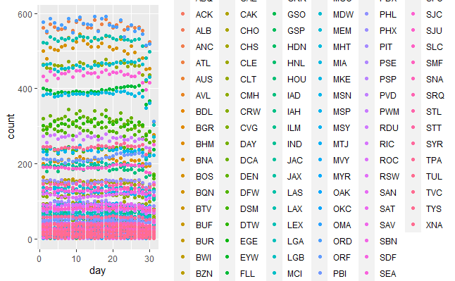

```r
daily %>%
  ggplot(aes(x = day, y = count, color = dest)) +
  geom_point()
```

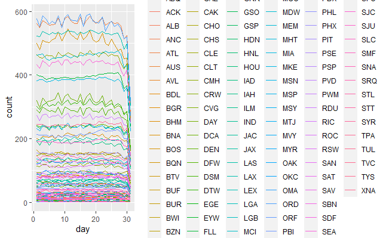

```r
daily %>%
  ggplot(aes(x = day, y = count, color = dest)) +
  geom_line()
```

```r
daily %>%
  distinct(dest)
```

| dest |
| --- |
| ABQ |
| ACK |
| ALB |
| ANC |
| ATL |
| AUS |
| AVL |
| BDL |
| BGR |
| BHM |

[output cut: 95 more lines]

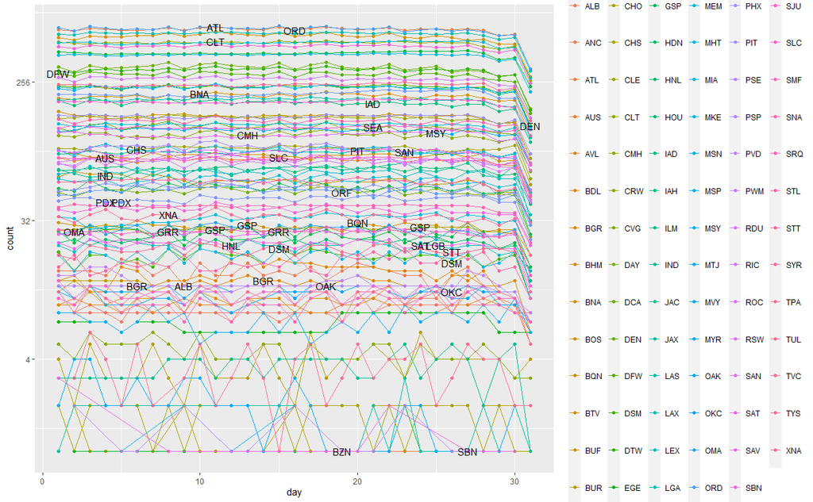

```r
daily %>%
  ggplot(aes(x = day, y = count, color = dest)) +
  geom_point() +
  geom_line() +
  scale_y_continuous(trans = "log2") +
  geom_text(data = daily %>% ungroup() %>%
              sample_n(size = 40),
            aes(label = dest), color = "black") +
  theme(legend.key.size = unit(1.5, "cm"),
  legend.key.width = unit(0.5,"cm"))
```

```r
daily %>%
  ungroup() %>%
sample_n(40)
```

| dest | day | count |
| --- | --- | --- |
| IND | 20 | 70 |
| XNA | 1 | 34 |
| SNA | 18 | 29 |
| JAC | 31 | 1 |
| SJC | 26 | 10 |
| LAS | 9 | 194 |
| SYR | 24 | 55 |
| HNL | 27 | 24 |
| BDL | 5 | 16 |
| BDL | 4 | 11 |

[output cut: 30 more lines]

Try #2 with `dplyr 1.0.0`

Grouping the `tibble` by destination and using `slice_sample()`, we can obtain a random sample from each destination.

```r
dest_sample <- daily %>%
  group_by(dest) %>%
  slice_sample(1)

dest_sample
```

| dest | day | count |
| --- | --- | --- |
| ABQ | 28 | 9 |
| ACK | 30 | 9 |
| ALB | 18 | 13 |
| ANC | 3 | 1 |
| ATL | 1 | 563 |
| AUS | 17 | 82 |
| AVL | 27 | 9 |
| BDL | 29 | 11 |
| BGR | 28 | 12 |
| BHM | 20 | 10 |

[output cut: 95 more lines]

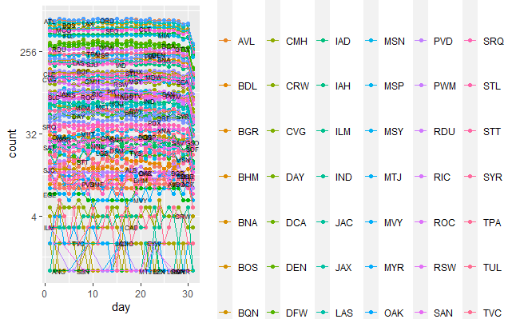

```r
daily %>%
  ggplot(aes(x = day, y = count, color = dest)) +
  geom_point() +
  geom_line() +
  scale_y_continuous(trans = "log2") +
  geom_text(data = dest_sample, size = 2,
            aes(label = dest), color = "black") +
  theme(legend.key.size = unit(1.5, "cm"),
  legend.key.width = unit(0.5,"cm"))
```

# `gapminder` dataset

```r
gap <- read_csv("gapminder-health-income.csv") %>%
  mutate(population = log10(population))
gap
```

| country | income | health | population |
| --- | --- | --- | --- |
| Afghanistan | 1925 | 57.63 | 7.512238 |
| Albania | 10620 | 76.00 | 6.461900 |
| Algeria | 13434 | 76.50 | 7.598424 |
| Andorra | 46577 | 84.10 | 4.848023 |
| Angola | 7615 | 61.00 | 7.398322 |
| Antigua and Barbuda | 21049 | 75.20 | 4.962928 |
| Argentina | 17344 | 76.20 | 7.637657 |
| Armenia | 7763 | 74.40 | 6.479678 |
| Australia | 44056 | 81.80 | 7.379649 |
| Austria | 44401 | 81.00 | 6.931691 |

[output cut: 177 more lines]

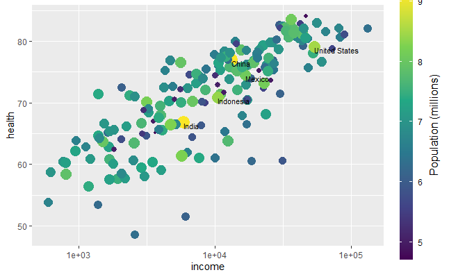

```r
gap %>%
  ggplot(aes(x = income, y = health,
             color = population,
             size = population)) +
  geom_point() +
  scale_color_viridis_c(
    guide = guide_colorbar(title.position = "right",
                          title.theme = element_text(angle = 90),
                          barheight = 20)) +
  scale_x_log10() +
  guides(size = FALSE) +
  geom_text(data = gap %>% filter(country %in%
                                    c("India",
                                      "Indonesia",
                                      "China",
                                      "United States",
                                      "Mexico")),
            aes(label = country),
            color = "black",
            size = 3,
            check_overlap = TRUE,
            hjust = 0,
            vjust = 1) +
  theme(legend.key.size = unit(1.5, "cm"),
  legend.key.width = unit(0.5,"cm"),
  legend.title.align = 0.5
  ) +
  labs(color = "Population (millions)")
```